# HW4

Author

Yufan Li

## Homework 4

Github Repo Link: https://github.com/YufanLi2002/STATS506.git

### Problem 1 - Tidyverse

Use the **tidyverse** for this problem. In particular, use piping and **dplyr** as much as you are able. **Note**: Use of any deprecated functions will result in a point loss.

Install and load the package [**nycflights13**](https://cran.r-project.org/package=nycflights13).

a. Generate a table (which can just be a nicely printed tibble) reporting the mean and median departure delay per airport. Generate a second table (which again can be a nicely printed tibble) reporting the mean and median arrival delay per airport. Exclude any destination with under 10 flights. Do this exclusion through code, not manually.

Additionally,

- Order both tables in descending mean delay.
- Both tables should use the airport *names* not the airport *codes*.
- Both tables should print all rows.

```r
setwd("~/Documents/GitHub/STATS506/HW4")
# install.packages("nycflights13")
## load all necessary packages and data sets
library(tidyverse)
library(dplyr)
library(nycflights13)
data(flights)
data(airports)

# First table with the mean and median departure delay for each departure airport
table1 <- flights %>%
  # Group data by the origin airport code
  group_by(origin) %>%
  # Filter to keep groups with at least 10 flights and remove rows with missing departure delay
  filter(n() >= 10 & !is.na(dep_delay)) %>%
  # Calculate the mean and median departure delay for each airport
  summarise(
    mean_dep_delay = mean(dep_delay),
    median_dep_delay = median(dep_delay)
  ) %>%
  # Join with the airports dataset to get the airport names, matching origin code to faa code
  inner_join(airports, by = c("origin" = "faa")) %>%
  # Select only the columns for airport name, mean, and median departure delay
  select(name, mean_dep_delay, median_dep_delay) %>%
  # Sort the table by mean departure delay in descending order
  arrange(desc(mean_dep_delay)) %>%
  # Rename 'name' column to 'airport'
  rename(airport = name) %>%
  # Print the entire table without truncation
  print(n = Inf)
```

```
# A tibble: 3 × 3
  airport             mean_dep_delay median_dep_delay
  <chr>                        <dbl>            <dbl>
1 Newark Liberty Intl           15.1               -1
2 John F Kennedy Intl           12.1               -1
3 La Guardia                    10.3               -3
```

```r
# Second table with the mean and median arrival delay for each destination airport
table2 <- flights %>%
  # Group data by the destination airport code
  group_by(dest) %>%
  # Filter to keep groups with at least 10 flights and remove rows with missing arrival delay
  filter(n() >= 10 & !is.na(arr_delay)) %>%
  # Calculate the mean and median arrival delay for each destination airport
  summarise(
    mean_arr_delay = mean(arr_delay, na.rm = TRUE),
    median_arr_delay = median(arr_delay, na.rm = TRUE)
  ) %>%
  # Join with the airports dataset to get the airport names, matching destination code to faa code
  inner_join(airports, by = c("dest" = "faa")) %>%
  # Select only the columns for airport name, mean, and median arrival delay
  select(name, mean_arr_delay, median_arr_delay) %>%
  # Sort the table by mean arrival delay in descending order
  arrange(desc(mean_arr_delay)) %>%
  # Rename 'name' column to 'airport' for clarity
  rename(airport = name) %>%
  # Print the entire table without truncation
  print(n = Inf)
```

```
# A tibble: 98 × 3
   airport                                mean_arr_delay median_arr_delay
   <chr>                                           <dbl>            <dbl>
 1 "Columbia Metropolitan"                       41.8                28
 2 "Tulsa Intl"                                  33.7                14
 3 "Will Rogers World"                           30.6                16
 4 "Jackson Hole Airport"                        28.1                15
 5 "Mc Ghee Tyson"                               24.1                 2
 6 "Dane Co Rgnl Truax Fld"                      20.2                 1
 7 "Richmond Intl"                               20.1                 1
 8 "Akron Canton Regional Airport"               19.7                 3
 9 "Des Moines Intl"                             19.0                 0
10 "Gerald R Ford Intl"                          18.2                 1
11 "Birmingham Intl"                             16.9                -2
12 "Theodore Francis Green State"                16.2                 1
```

[output cut: 86 more lines]

b. How many flights did the aircraft model with the fastest average speed take? Produce a tibble with 1 row, and entries for the model, average speed (in MPH) and number of flights.

```r
## load the necessary data sets
data(planes)
data(airlines)

# Calculate speed (in MPH) and find the aircraft model with the fastest average speed
fastest_aircraft <- flights %>%
  filter(!is.na(distance), !is.na(air_time), air_time > 0) %>%
  # Filter out rows with missing or zero air_time
  mutate(speed_mph = distance / (air_time / 60)) %>%
  # Calculate speed in MPH
  inner_join(planes, by = "tailnum") %>%
  # Join with planes to get model info
  group_by(model) %>%
  # Group by model
  summarise(
    avg_speed_mph = mean(speed_mph, na.rm = TRUE),
    num_flights = n()
  ) %>%
  arrange(desc(avg_speed_mph)) %>%
  # Arrange by average speed in descending order
  slice(1) %>%
  # Select the fastest aircraft model
  as_tibble()
  # Convert to tibble for a nicer output

fastest_aircraft
```

```
# A tibble: 1 × 3
  model   avg_speed_mph num_flights
  <chr>           <dbl>       <int>
1 777-222          483.           4
```

### Problem 2 - get_temp()

Use the **tidyverse** for this problem. In particular, use piping and **dplyr** as much as you are able. **Note**: Use of any deprecated functions will result in a point loss.

Load the Chicago NNMAPS data we used in the visualization lectures. Write a function `get_temp()` that allows a user to request the average temperature for a given month. The arguments should be:

- `month`: Month, either a numeric 1-12 or a string.
- `year`: A numeric year.
- `data`: The data set to obtain data from.
- `celsius`: Logically indicating whther the results should be in celsius. Default `FALSE`.
- `average_fn`: A function with which to compute the mean. Default is `mean`.

The output should be a numeric vector of length 1. The code inside the function should, as with the rest of this problem, use the **tidyverse**. Be sure to sanitize the input.

Prove your code works by evaluating the following. Your code should produce the result, or a reasonable error message.

```r
# Load the data set
nnmaps <- read.csv("chicago-nmmaps.csv")

#' Get Average Temperature for a Specified Month and Year
#'
#' This function calculates the average temperature for a specified month and year
#' from a given dataset. The temperature can be returned in either Fahrenheit
#' or Celsius, and a custom averaging function can be specified.
#'
#' @param month A number (1-12) or the full/abbreviated name of the month (e.g., "January" or "Jan").
#' @param year An integer specifying the year for which to calculate the average temperature.
#' @param data A data frame containing temperature data with required columns: "month",
#' "month_numeric", "year", and "temp".
#' @param celsius Logical, if TRUE, converts the temperature from Fahrenheit to Celsius. Defaults to FALSE.
#' @param average_fn A function for calculating the average temperature. Defaults to `mean`.
#'
#' @return The average temperature for the specified month and year in Fahrenheit (or Celsius if requested).
#' Returns an error message if input validation fails or no data is found.
#'
#' @examples
#'
#' get_temp("Jan", 2023, nnmaps, celsius = TRUE)
#' get_temp(1, 2023, nnmaps, average_fn = median)
#'
#' @export
#'
get_temp <- function(month, year, data, celsius = FALSE, average_fn = mean) {
  # Input validation: Check if 'data' is a data frame
  if (!is.data.frame(data)) {
    return("'data' must be a data frame")
  }

  # Check if required columns are present in 'data'
  # Since these columns are necessary for filtering and calculating temperature
  required_cols <- c("month", "month_numeric", "year", "temp")
  if (!all(required_cols %in% names(data))) {
    return("Data must contain required columns")
  }

  # Standardize the month input
  if (is.character(month)) {
    # Convert to 3-letter abbreviation if input is a full month name
    month_abbr <- substr(month, 1, 3)

    # Check if the abbreviation exists in the data; if not, try full name
    if (!month_abbr %in% unique(data$month)) {
      # Try matching the full month name in English (e.g., "January")
      month_num <- match(tolower(month), tolower(month.name))

      # Return error if month name is invalid
      if (is.na(month_num)) {
        return("Invalid month name")
      }

      # Convert matched month to its 3-letter abbreviation
      month_abbr <- month.abb[month_num]
    }

    # Filter data for specified month (abbreviation) and year
    filtered_data <- data %>%
      filter(month == month_abbr, year == !!year)

  } else if (is.numeric(month)) {
    # Validate numeric month input is within the range 1-12
    if (month < 1 || month > 12) {
      return("Month must be between 1 and 12")
    }

    # Filter data for specified numeric month and year
    filtered_data <- data %>%
      filter(month_numeric == !!month, year == !!year)
  } else {
    # Return error if month is neither numeric nor a valid name
    return("Month must be either a number (1-12) or a month name")
  }

  # Check if any rows remain after filtering for the specified month and year
  if (nrow(filtered_data) == 0) {
    return("No data found for specified month and year")
  }

  # Calculate the average temperature for the filtered data
  # Check if 'average_fn' supports 'na.rm' argument to handle NA values if needed
  if ("na.rm" %in% names(formals(average_fn))) {
    # Use 'average_fn' with 'na.rm = TRUE' to ignore any missing temperature values
    result <- filtered_data %>%
      summarise(temp = average_fn(temp, na.rm = TRUE)) %>%
      pull(temp)
  } else {
    # Use 'average_fn' without 'na.rm' if the function doesn't support it
    result <- filtered_data %>%
      summarise(temp = average_fn(temp)) %>%
      pull(temp)
  }

  # Convert temperature to Celsius if 'celsius' argument is TRUE
  if (celsius) {
    result <- (result - 32) * 5 / 9
  }

  # Return the calculated temperature
  return(result)
}
```

```r
## the test cases for the function
# Example usage (use your data frame as nnmaps):
get_temp("Apr", 1999, data = nnmaps)
```

```
[1] 49.8
```

```r
get_temp("Apr", 1999, data = nnmaps, celsius = TRUE)
```

```
[1] 9.888889
```

```r
get_temp(10, 1998, data = nnmaps, average_fn = median)
```

```
[1] 55
```

```r
get_temp(13, 1998, data = nnmaps)   # Should return an error for invalid month
```

```
[1] "Month must be between 1 and 12"
```

```r
get_temp(2, 2005, data = nnmaps)    # Should return an error if data for 2005 is unavailable
```

```
[1] "No data found for specified month and year"
```

```r
get_temp("November", 1999, data = nnmaps, celsius = TRUE, average_fn = function(x) {
   x %>% sort -> x
   x[2:(length(x) - 1)] %>% mean %>% return
 })
```

```
[1] 7.301587
```

### Problem 3 - Visualization

Note: This is, intentionally, a very open-ended question. There is no “right” answer. The goal is for you to explore your plotting options, and settle on something reasonable. You can use base R, ggplot, or soemthing else. You’ll likely have to look online for resources on plotting beyond what we covered in class.

This dataset lists characteristics of [art sales](https://springernature.figshare.com/articles/dataset/Buying_a_Work_of_Art_or_an_Artist_Exploring_the_Impact_of_Visual_and_Social_Features_on_Art_Prices/24746268?file=43477980). Download the file named “df_for_ml_improved_new_market” (NOT the “df_for_ml_improved_new_market_1” version!). For each of the following, produce a publication-ready plot which demonstrates the answer to the question. Use your plot to support an argument for your question.

1. Is there a change in the sales price in USD over time?
2. Does the distribution of genre of sales across years appear to change?
3. How does the genre affect the change in sales price over time?

You will be graded on:

1. Is the type of graph & choice of variables appropriate to answer the question?
2. Is the graph clear and easy to interpret?
3. Is the graph publication ready?

part (a)

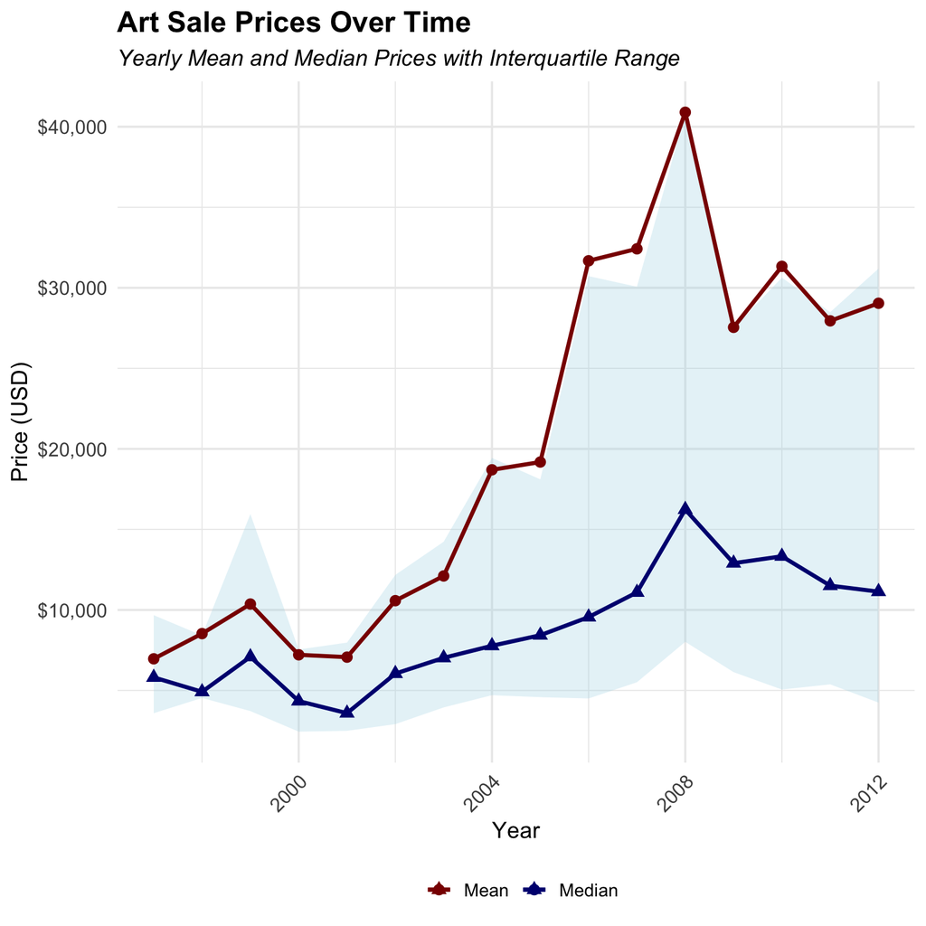

```r
# load the data set and all necessary packages
artSale <- read.csv("df_for_ml_improved_new_market.csv")
library(ggplot2)
library(dplyr)
library(scales)
# Calculate yearly summary statistics for art sale prices
yearly_stats <- artSale %>%
  group_by(year) %>%  # Group data by 'year'
  summarise(
    median_price = median(price_usd),  # Calculate median price for each year
    mean_price = mean(price_usd),      # Calculate mean price for each year
    q25 = quantile(price_usd, 0.25),   # Calculate 25th percentile price (lower quartile)
    q75 = quantile(price_usd, 0.75),   # Calculate 75th percentile price (upper quartile)
    max = max(price_usd),              # Calculate maximum price for each year
    min = min(price_usd)               # Calculate minimum price for each year
  )

# Create a plot of yearly art sale price statistics
ggplot(data = yearly_stats) +
  # Add shaded area representing the IQR
  geom_ribbon(aes(x = year, ymin = q25, ymax = q75),
              fill = "lightblue", alpha = 0.3) +
  # plot line for yearly mean price with custom color and thickness
  geom_line(aes(x = year, y = mean_price, color = "Mean"),
            size = 1.2) +
  #plot line for yearly median price with custom color and thickness
  geom_line(aes(x = year, y = median_price, color = "Median"),
            size = 1.2) +
  # add points for mean price with specific shape and size for visibility
  geom_point(aes(x = year, y = mean_price, color = "Mean"),
             size = 3, shape = 16) +
  # add points for median price with different shape for distinction
  geom_point(aes(x = year, y = median_price, color = "Median"),
             size = 3, shape = 17) +
  # Format y-axis labels to display in dollar format
  scale_y_continuous(labels = dollar_format()) +
  # Set custom colors for mean and median lines
  scale_color_manual(values = c("Mean" = "darkred", "Median" = "navy")) +
  # Add plot title, subtitle, and axis labels
  labs(title = "Art Sale Prices Over Time",
       subtitle = "Yearly Mean and Median Prices with Interquartile Range",
       x = "Year",
       y = "Price (USD)",
       color = "Measure") +
  # Apply minimal theme with increased base text size for readability
  theme_minimal(base_size = 14) +
  # Customize title, subtitle, legend, and axis text for better presentation
  theme(
    plot.title = element_text(size = 18, face = "bold"),
    # Set title font size and boldness for emphasis
    plot.subtitle = element_text(size = 14, face = "italic"),
    # Set subtitle font size and italic style for distinction
    legend.position = "bottom",
    # Position the legend below the plot for a cleaner layout
    legend.title = element_blank(),
    # Remove the legend title to simplify the legend display
    axis.text.x = element_text(angle = 45, hjust = 1),
    # Rotate x-axis labels 45 degrees to prevent overlap and improve readability
    axis.text = element_text(size = 12),
    # Increase size of axis text for better readability
    axis.title = element_text(size = 14)
    # Increase size of axis titles to match overall plot text size
  )
```

After computing the mean and median sale prices for each year from 1997 to 2012, and generating the graph above, we can clearly see that there IS a change in the sales price in USD over time. Here is a more detailed explanation:

- The plot shows a clear upward trend in the sales prices over the year 2000 to 2008 and decreased from 2008 to 2012, indicated by the consistent behavior in both the mean and median lines. This trend suggests that, on average, artworks are selling for higher prices each year from 2000 to 2008 and a relatively lower prices from 2008 to 2012.
- the interquartile range (IQR), represented by the shaded ribbon between the 25th and 75th percentiles, widens over time. This widening indicates greater variability in sales prices, suggesting that while prices are generally increasing, the distribution of prices is becoming more dispersed. It indicates that while most prices may be increasing, a portion of particularly high sales is pulling the average up, leading to greater variation within each year.

Part (b)

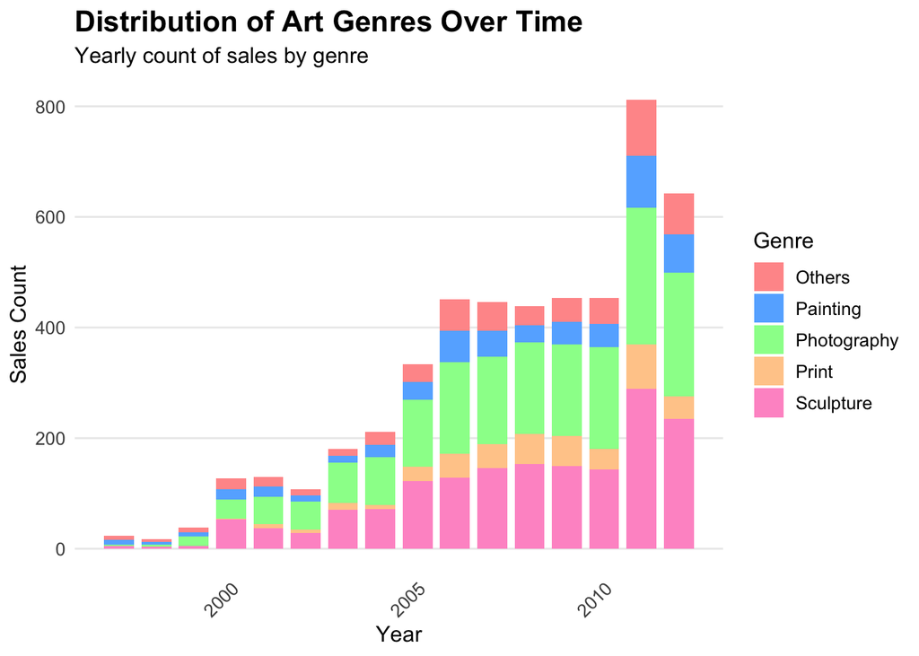

```r
# Data processing
genre_distribution <- artSale %>%
  # Convert wide format genres into a long format where each row is a genre for a sale
  tidyr::pivot_longer(
    cols = c(Genre___Photography, Genre___Print, Genre___Sculpture, Genre___Painting, Genre___Others),  # Select genre columns
    names_to = "Genre",      # Rename the column that holds genre names
    values_to = "IsGenre"    # Rename the column that indicates whether sale belongs to the genre
  ) %>%
  # Filter for rows where the genre is present (IsGenre == 1)
  filter(IsGenre == 1) %>%
  # Clean up genre names by removing prefix "Genre___"
  mutate(Genre = gsub("Genre___", "", Genre)) %>%
  # Group by year and genre to calculate yearly counts for each genre
  group_by(year, Genre) %>%
  summarize(count = n(), .groups = 'drop') %>%  # Count number of sales per genre per year
  # Calculate total sales and proportion of each genre within each year
  group_by(year) %>%
  mutate(total_sales_year = sum(count),                 # Total sales for the year
         proportion = count / total_sales_year) %>%     # Proportion of sales for each genre
  ungroup()


# Create the stacked bar plot
ggplot(genre_distribution,
       aes(x = year,       # X-axis represents the year
           y = count,      # Y-axis represents the count of sales for each genre
           fill = Genre)) +  # Fill color represents different genres
  # Create stacked bars for genre distribution within each year
  geom_bar(stat = "identity",    # Use raw values in 'count' for bar height
           position = "stack",   # Stack bars within each year to show genre distribution
           width = 0.8) +        # Set bar width to make spacing clearer
  # Custom color scheme for genre bars
  scale_fill_manual(values = c("#FF9999", "#66B2FF", "#99FF99", "#FFCC99", "#FF99CC")) +
  # Labels and titles for the plot
  labs(title = "Distribution of Art Genres Over Time",   # Main plot title
       subtitle = "Yearly count of sales by genre", # Subtitle for more context
       x = "Year",             # X-axis label
       y = "Sales Count",  # Y-axis label
       fill = "Genre") +       # Legend title
  # Theme customization for visual styling
  theme_minimal() +  # Use a minimal theme for a clean look
  theme(
    plot.title = element_text(size = 16, face = "bold"),    # Bold and size-adjusted title
    plot.subtitle = element_text(size = 12),                # Subtitle with smaller font
    axis.title = element_text(size = 12),                   # Axis titles size adjustment
    axis.text = element_text(size = 10),                    # Axis labels size adjustment
    axis.text.x = element_text(angle = 45, hjust = 1),      # Angle x-axis labels for readability
    legend.position = "right",                              # Position legend on the right side
    legend.title = element_text(size = 12),                 # Legend title size adjustment
    legend.text = element_text(size = 10),                  # Legend labels size adjustment
    panel.grid.major.x = element_blank(),                   # Remove major vertical grid lines
    panel.grid.minor = element_blank()                      # Remove minor grid lines for clarity
  )
```

Based on stacked bar plot computed above, the distribution of genre of sales across years does appear to change. we can clearly see that there is an overall increasing trend for the distribution of genre of sales, which indicates that there is a wider spread across all 5 genres, reflecting potentially diversified sales patterns.

Part (c)

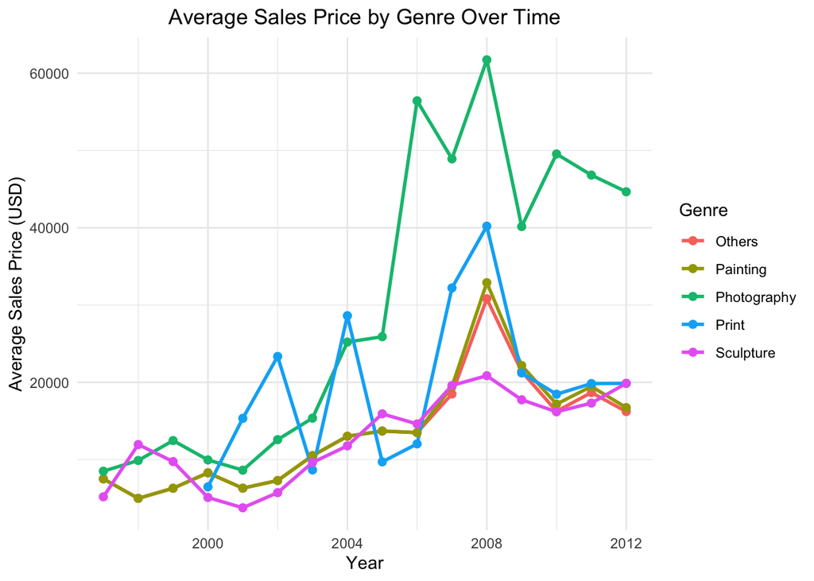

```r
# Calculate the average sales price by genre and year
genre_price_trends <- artSale %>%
  # Convert wide format genres into long format where each row represents a genre for a sale
  tidyr::pivot_longer(
    cols = c(Genre___Photography, Genre___Print, Genre___Sculpture, Genre___Painting, Genre___Others),  # Select genre columns
    names_to = "Genre",       # Create a new column for genre names
    values_to = "IsGenre"     # Create a new column indicating if sale belongs to the genre
  ) %>%
  # Filter rows where the genre is present (IsGenre == 1)
  filter(IsGenre == 1) %>%
  # Clean up genre names by removing the prefix "Genre___"
  mutate(Genre = gsub("Genre___", "", Genre)) %>%
  # Group data by year and genre to calculate average sales price for each genre within each year
  group_by(year, Genre) %>%
  # Calculate the average price of sales in USD, removing missing values
  summarize(avg_price = mean(price_usd, na.rm = TRUE), .groups = 'drop')  # Compute average price

# Plot average sales price by genre over time
ggplot(genre_price_trends, aes(x = year, y = avg_price, color = Genre)) +
  # Add lines to connect average price points over time for each genre
  geom_line(size = 1) +
  # Add points to highlight average price values at each year
  geom_point(size = 2) +
  # Labels for plot title, axis titles, and legend
  labs(title = "Average Sales Price by Genre Over Time",   # Main plot title
       x = "Year",                # X-axis label
       y = "Average Sales Price (USD)",  # Y-axis label
       color = "Genre") +         # Legend title
  # Minimal theme for a clean plot style
  theme_minimal() +
  # Center the plot title for aesthetic alignment
  theme(plot.title = element_text(hjust = 0.5))
```